# Perinatal HIV exposure and child health in the first 24 months of life

## 0.1 Preliminaries

```r
library(skimr)
library(car)
library(rms)
library(MASS)
library(broom)
library(lars)
library(GGally)
library(simputation)
library(tidyverse)
```

# 1 Task 1: Data Source

These data come from an observational mother-infant cohort study conducted in western Kenya from 2012-2016. My research mentor (Arlene Dent) is the study PI.

# 2 Task 2: Load and Tidy the Data

```r
chap <- read.csv("Project1_CHAP.csv") %>% tbl_df
```

```r
chap$HIV <- factor(chap$HIV, levels=0:1,
                    labels=c("HUU","HEU"))
chap$sex <- factor(chap$sex, levels=1:2, labels=c("Male", "Female"))
chap$sick_f <- factor(chap$sick_f, levels=0:2, labels=c("none", "1-4", ">=5"), ordered=TRUE)
chap$MIP <- factor(chap$MIP, levels=0:2, labels=c("none", "1", ">=2"), ordered=TRUE)
chap$edu <- factor(chap$edu, levels=0:3, labels=c("none", "lower primary", "upper primary", "secondary or higher"), ordered=TRUE)
chap$UM <- factor(chap$UM, levels=0:1, labels=c("No", "Yes"))
chap$SM <- factor(chap$SM, levels=0:1, labels=c("No", "Yes"))
chap$Sx_malaria <- factor(chap$Sx_malaria, levels=0:1, labels=c("No", "Yes"))
```

I created and labeled several factors that may be included as predictor variables.

# 3 Task 3: Listing of My Tibble

```r
chap
```

```
# A tibble: 114 x 21
      ID HIV   sex    UM_sum UM    SM_sum SM    Sx_malaria  PfPos  sick
   <dbl> <fct> <fct>   <dbl> <fct>  <dbl> <fct> <fct>       <dbl> <dbl>
 1  1.00 HUU   Female   0    No      0    No    No         0.125   1.00
 2  9.00 HUU   Male     3.00 Yes     0    No    Yes        0.375   1.00
 3 10.0  HUU   Female   2.00 Yes     0    No    Yes        0.133   1.00
 4 12.0  HUU   Male     0    No      1.00 Yes   Yes        0.267   1.00
 5 15.0  HUU   Female   0    No      0    No    No         0.500   0
 6 19.0  HUU   Female   0    No      0    No    No         0.200   0
 7 20.0  HUU   Female   4.00 Yes     0    No    Yes        0.412   1.00
 8 28.0  HUU   Female   0    No      0    No    No         0       1.00
 9 33.0  HUU   Male     2.00 Yes     0    No    Yes        0.300   1.00
10 37.0  HEU   Male     1.00 Yes     0    No    Yes        0.0714  1.00
# ... with 104 more rows, and 11 more variables: sick_sum <dbl>,
#   sick_f <ord>, MIP <ord>, MUAC <dbl>, edu <ord>, hosp <dbl>, age <dbl>,
#   weight <dbl>, height <dbl>, HC <dbl>, temp <dbl>
```

```r
skim_with(numeric = list(hist = NULL), integer = list(hist = NULL))
chap %>% skim(-ID)
```

```
Skim summary statistics
 n obs: 114
 n variables: 21

Variable type: factor
   variable missing complete   n n_unique
        edu       3      111 114        4
        HIV       0      114 114        2
        MIP       9      105 114        3
        sex       0      114 114        2
     sick_f       0      114 114        3
         SM       0      114 114        2
 Sx_malaria       0      114 114        2
         UM       0      114 114        2
                        top_counts ordered
 upp: 43, low: 42, non: 17, sec: 9    TRUE
           HUU: 83, HEU: 31, NA: 0   FALSE
    non: 52, >=2: 28, 1: 25, NA: 9    TRUE
           Mal: 57, Fem: 57, NA: 0   FALSE
  1-4: 55, >=5: 37, non: 22, NA: 0    TRUE
           No: 100, Yes: 14, NA: 0   FALSE
            Yes: 60, No: 54, NA: 0   FALSE
            No: 58, Yes: 56, NA: 0   FALSE

Variable type: numeric
 variable missing complete   n  mean   sd   p0   p25 median   p75 p100
      age       0      114 114 24.33 0.42 23.3 24.17 24.31  24.43 26.2
       HC       0      114 114 47.63 1.86 40   47    48     49    52
   height       0      114 114 80.85 4.39 70   78    81     84    91
     hosp       0      114 114  0.17 0.37  0    0     0      0     1
     MUAC       0      114 114 15.5  1.13 12.8 14.8  15.5   16.15 18
    PfPos       0      114 114  0.15 0.15  0    0     0.087  0.26  0.6
     sick       0      114 114  0.81 0.4   0    1     1      1     1
 sick_sum       0      114 114  3.65 3.46  0    1     3      5    18
   SM_sum       0      114 114  0.21 0.63  0    0     0      0     3
     temp       0      114 114 36.58 1.11 35.4 36.2  36.5   36.7  46.6
   UM_sum       0      114 114  0.99 1.45  0    0     0      2     8
   weight       0      114 114 11.12 1.49  8   10    11     12    16
```

# 4 Task 4: Code Book

[output not shown]

# 5 Task 5: My Subjects

The data describe a cohort of 114 children from western Kenya whose mothers were enrolled in the study during their first prenatal clinic visits and followed throughout pregnancy. At delivery, infants were enrolled and followed at 6, 10, 14, and 18 weeks, and 6, 9, 12, 15, 18, 21, and 24 months of age, and for any interim sick visit. Anthropometric data included here were collected at 24 months of age.

# 6 Task 6: My Variables

The primary predictor variable of interest is `HIV` exposure (all infants are HIV-uninfected: `HUU` are unexposed uninfected, and `HEU` are exposed uninfected). Studies have shown that among HIV-uninfected infants and children, those born to mothers with vs. without HIV had increased moribidity and mortality risks in the first few years of life.

`PfPos` is the proportion of all visits in the first 24 months of life in which the child tested positive for Plasmodium falciparum (malaria) by PCR or blood smear, and includes asymptomatic and symptomatic infections (this area of western Kenya has year-round, intense malaria transmission). `UM`, `UM_sum`, `SM`, `SM_sum` describe the number of times a child was diagnosed with uncomplicated (UM) or severe (SM) malaria in the first 24 months. `Sx_malaria` is a binary variable that describes whether uncomplicated malaria (UM) or severe malaria (SM) was diagnosed in the first 24 months of life.

`sick`, `sick_sum`, and `sick_f` describe the number of sick visits the child had in the first 24 months of life (most common diagnoses were malaria, respiratory infections, and gastrointestinal infections). `MIP` describes the number of times subjects’ mothers were diagnosed with malaria during pregnancy (none, 1, or 2 or more times).

`MUAC` is the mid-upper arm circumference in cm, measured at 24 months of age. MUAC is a reliable measure of nutritional status in children and is used to screen for malnutrition (MUAC may be a more reliable measure than weight, which can be influenced by acute dehydration secondary to diarrhea and gastrointestinal illness).

`edu` describes the highest level of education that the subjects’ mothers received (none, lower primary, upper primary, and secondary school or higher). This variable was chosen as a measure of socioeconomic status that might influence child nutrition and health. Overall, the level of education for mothers in this cohort was low.

`hosp` describes whether the child was ever hospitalized in the first 24 months of life, and reflects whether a child was diagnosed with a severe illness (most commonly with severe malaria, lower respiratory tract infection, and diarrhea/dehydration). Weight, height, head circumference, and temperature at 24 months are also included in the data.

# 7 Task 7: My Planned Linear Regression Model

`sick_sum` will be my outcome variable. Candidate predictor variables will include `HIV`, `sex`, `MUAC`, `edu`, and `MIP`. `MUAC` is a quantitative variable, and `edu` and `MIP` are multi-categorical.

# 8 Task 8: My Planned Logistic Regression Model

`Sx_malaria` will be my outcome variable. Candidate predictor variables will include `HIV`, `sex`, `MUAC`, `edu`, and `MIP`.

# 9 Task 9: Affirmation

This data set meets the requirement for minimum and maximum sample size (n = 114, with at least 100 rows with complete observations on all variables). Given the sample size of 114 (with 3 missing observations for edu), I will study only 4 regression inputs for each model. Each model will include a quantitative predictor (MUAC) and a multi-categorical predictor (MIP or edu). I am certain that it is completely appropriate for these data to be shared with anyone, without any conditions. There are no concerns about privacy or security.

# 10 Task 10: Linear Regression Model

## 10.1 Exploratory data analysis of the outcome variable `sick_sum` as well as the potential predictor variables.

Distribution of outcome variable `sick_sum`:

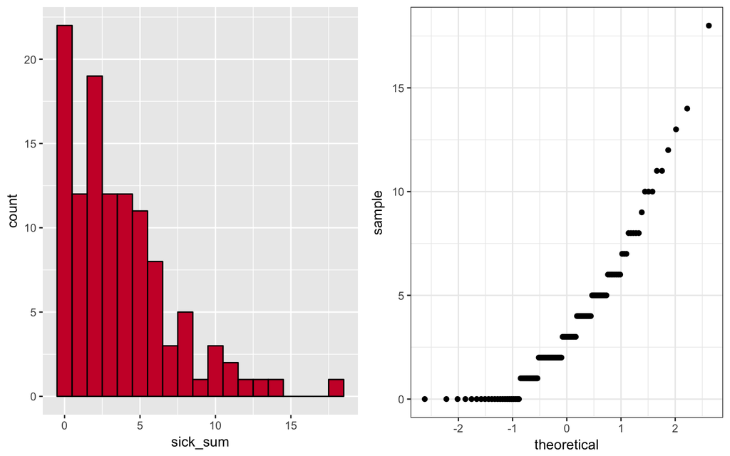

```r
h1 <- ggplot(chap, aes(x=sick_sum)) +
  geom_histogram(color="black", fill="#CC0033", binwidth = 1)

q1 <- ggplot(chap, aes(sample = sick_sum)) +
  geom_point(stat="qq") +
  theme_bw()

gridExtra::grid.arrange(h1, q1, nrow=1)
```

`sick_sum` has a strong right skew, with many subjects having values of 0.

Evaluate log transformation:

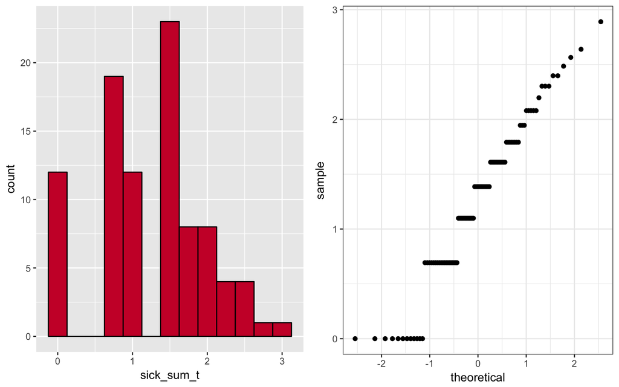

```r
chap <- chap %>% mutate(sick_sum_t = log(sick_sum))

h2 <- ggplot(chap, aes(x=sick_sum_t)) +
  geom_histogram(color="black", fill="#CC0033", binwidth = 0.25)

q2 <- ggplot(chap, aes(sample = sick_sum_t)) +
  geom_point(stat="qq") +
  theme_bw()

gridExtra::grid.arrange(h2, q2, nrow=1)
```

Log transformation of `sick_sum` results in a distribution that is not much better, and problematic since 22 observations now have non-finite values.

Transforming by log(sick_sum + 1) gives a distribution that is still skewed and contains many zeros:

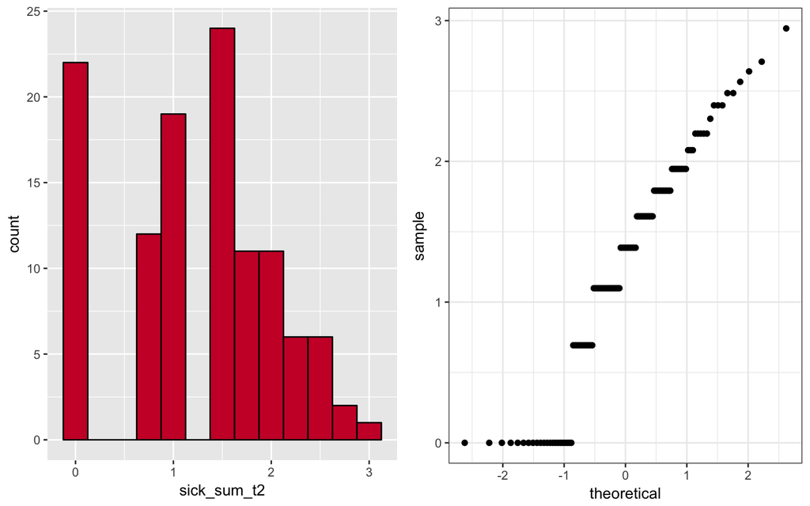

```r
chap <- chap %>% mutate(sick_sum_t2 = log(sick_sum+1))

h3 <- ggplot(chap, aes(x=sick_sum_t2)) +
  geom_histogram(color="black", fill="#CC0033", binwidth = 0.25)

q3 <- ggplot(chap, aes(sample = sick_sum_t2)) +
  geom_point(stat="qq") +
  theme_bw()

gridExtra::grid.arrange(h3, q3, nrow=1)
```

Because the transformations didn’t help and the outcome `sick_sum` is a count, I will perform Poisson regression. I considered performing zero-inflated Poisson, however, I do not think `sick_sum` technically has an excess of zeros because each subject was theoretically eligible to have a sick visit.

Before selecting and fitting a model, I will further explore the potential predictor variables.

HIV is the primary predictor:

```r
chap %>% group_by(HIV) %>% select(HIV, sick_sum) %>% skim()
```

```
Skim summary statistics
 n obs: 114
 n variables: 2
 group variables: HIV

Variable type: numeric
 HIV variable missing complete  n mean   sd p0 p25 median p75 p100
 HUU sick_sum       0       83 83 4    3.63  0 1.5      3 5.5   18
 HEU sick_sum       0       31 31 2.71 2.82  0 0        2 4     10
```

There are no missing values. There are 83 HUU subjects and 31 HEU subjects. The means are higher than the medians in both groups, indicating the right skew noted above. Both means and medians are higher in the HUU group compared to the HEU group (HIV unexposed infants with more sick visits compared to HIV exposed infants, which is in contrast to several other reports in the literature – will discuss more below).

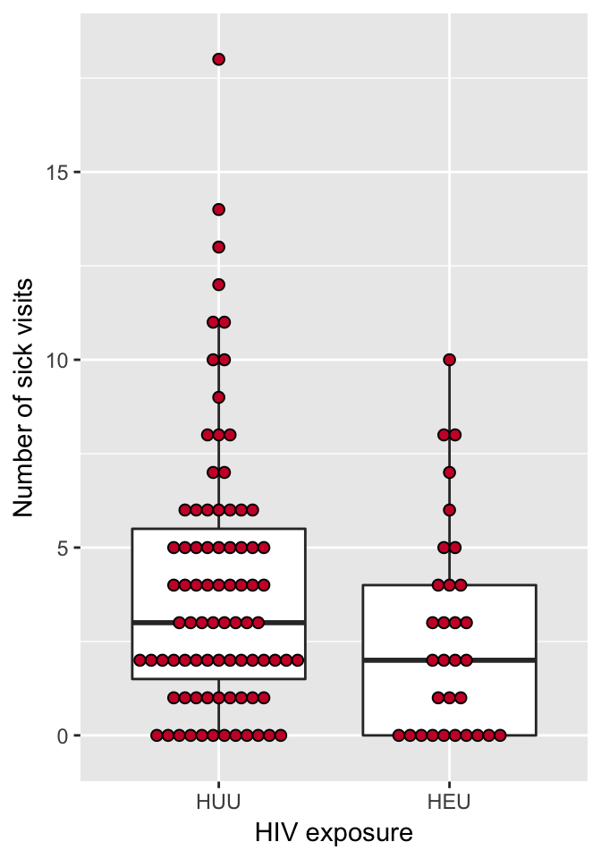

```r
p <- ggplot(chap, aes(x = HIV, y = sick_sum)) +
  geom_boxplot() +
  geom_dotplot(binaxis = "y", stackdir = "center", dotsize = 0.5, fill = "#CC0033") +
  labs(x = "HIV exposure", y = "Number of sick visits")
p
```

**Other potential predictors: `sex`, `MUAC`, `PfPos`, `edu`, and `MIP`**

```r
chap %>% group_by(sex) %>% select(sex, sick_sum) %>% skim()
```

```
Skim summary statistics
 n obs: 114
 n variables: 2
 group variables: sex

Variable type: numeric
    sex variable missing complete  n mean   sd p0 p25 median p75 p100
   Male sick_sum       0       57 57 3.84 3.52  0   1      3   6   18
 Female sick_sum       0       57 57 3.46 3.43  0   1      3   5   14
```

There are equal numbers of males and females, with no missing values. Means and medians are similar for males compared to females.

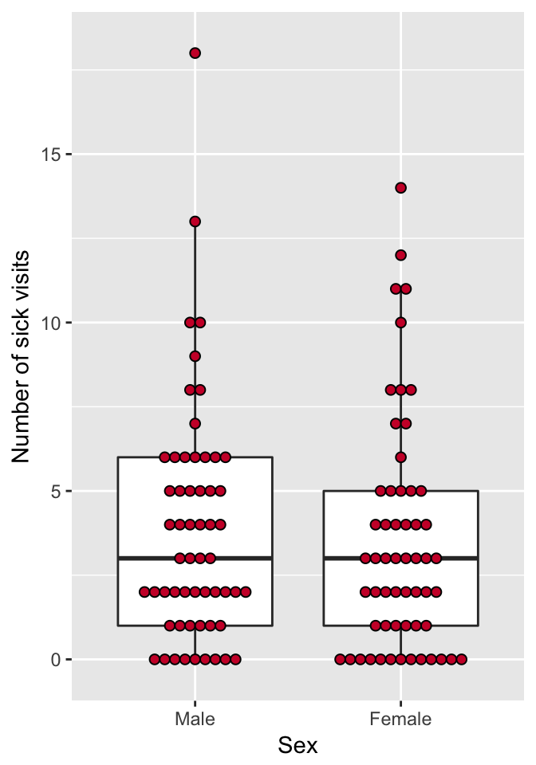

```r
p2 <- ggplot(chap, aes(x = sex, y = sick_sum)) +
  geom_boxplot() +
  geom_dotplot(binaxis = "y", stackdir = "center", dotsize = 0.5, fill = "#CC0033") +
  labs(x = "Sex", y = "Number of sick visits")
p2
```

Mid-upper arm circumference (`MUAC`) and the proportion of visits with Pf infection (`PfPos`):

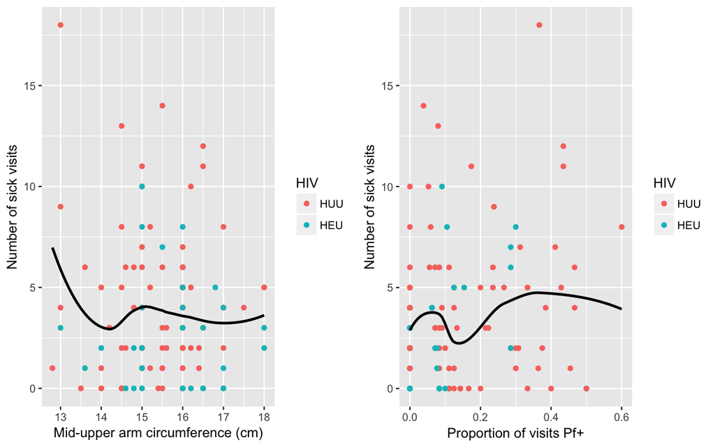

```r
p3 <- ggplot(chap, aes(x = MUAC, y = sick_sum)) +
  geom_point(aes(col=HIV)) +
  geom_smooth(method = "loess", color = "black", se = FALSE) +
  labs(x = "Mid-upper arm circumference (cm)", y = "Number of sick visits")


p3b <- ggplot(chap, aes(x = PfPos, y = sick_sum)) +
  geom_point(aes(col=HIV)) +
  geom_smooth(method = "loess", color = "black", se = FALSE) +
  labs(x = "Proportion of visits Pf+", y = "Number of sick visits")


gridExtra::grid.arrange(p3, p3b, nrow=1)
```

There do not seem to be relationships between `MUAC` or `PfPos` and `sick_sum`.

```r
chap %>% group_by(edu) %>% select(edu, sick_sum) %>% skim()
```

```
Skim summary statistics
 n obs: 114
 n variables: 2
 group variables: edu

Variable type: numeric
                 edu variable missing complete  n mean   sd p0 p25 median
                none sick_sum       0       17 17 4.71 3.37  0 2        4
       lower primary sick_sum       0       42 42 2.69 2.41  0 1        2
       upper primary sick_sum       0       43 43 4.35 4.12  0 1        3
 secondary or higher sick_sum       0        9  9 3.22 4.02  0 1        2
                <NA> sick_sum       0        3  3 2.33 2.08  0 1.5      3
 p75 p100
 6     12
 4      8
 6     18
 4     13
 3.5    4
```

There are 3 missing values for `edu`. The `sick_sum` values for those missing `edu` do not appear to be drastically different from the other subjects. There were only 9 mothers in the cohort with an education level of secondary school or higher, and 17 with no education. Most women had a primary school education. The mean and median `sick_sum` values do not appear to be different among the groups.

```r
chap %>% group_by(MIP) %>% select(MIP, sick_sum) %>% skim()
```

```
Skim summary statistics
 n obs: 114
 n variables: 2
 group variables: MIP

Variable type: numeric
  MIP variable missing complete  n mean   sd p0 p25 median p75 p100
 none sick_sum       0       52 52 3.63 3.03  0   1      3   5   12
    1 sick_sum       0       25 25 4.68 3.89  0   2      4   6   14
  >=2 sick_sum       0       28 28 3.36 3.99  0   1      2   5   18
 <NA> sick_sum       0        9  9 1.78 2.05  0   0      2   3    6
```

There are 9 missing values for `MIP` (malaria in pregnancy). The `sick_sum` values for those missing `MIP` do not appear to be drastically different from the other subjects, perhaps slightly lower. Fifty-two women had no malaria in pregnancy, 25 had one episode diagnosed, and 28 had 2 or more episodes. The mean and median `sick_sum` values do not appear to be different among the groups.

Evaluate missing values for `edu` and `MIP`:

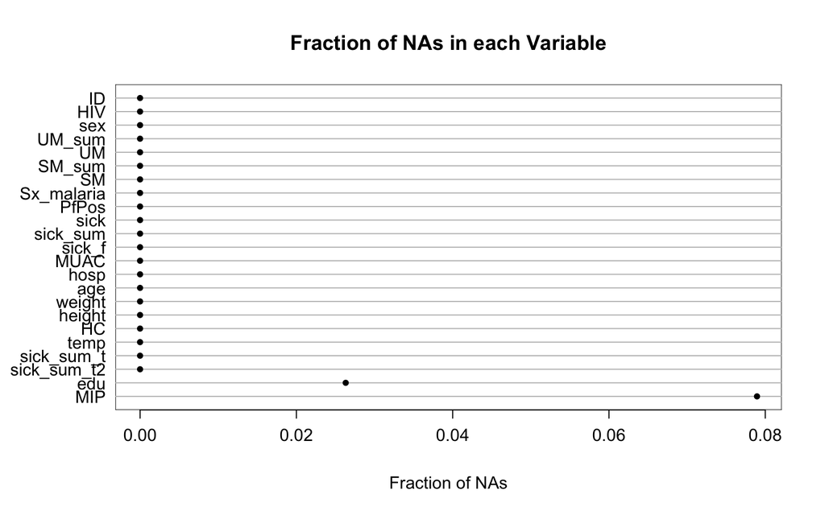

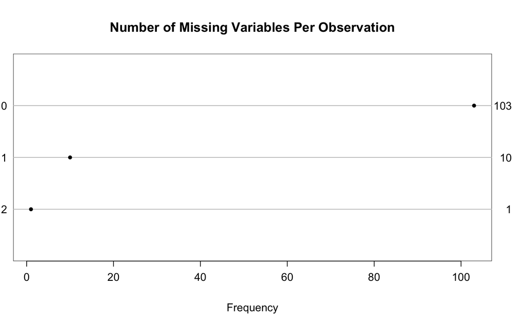

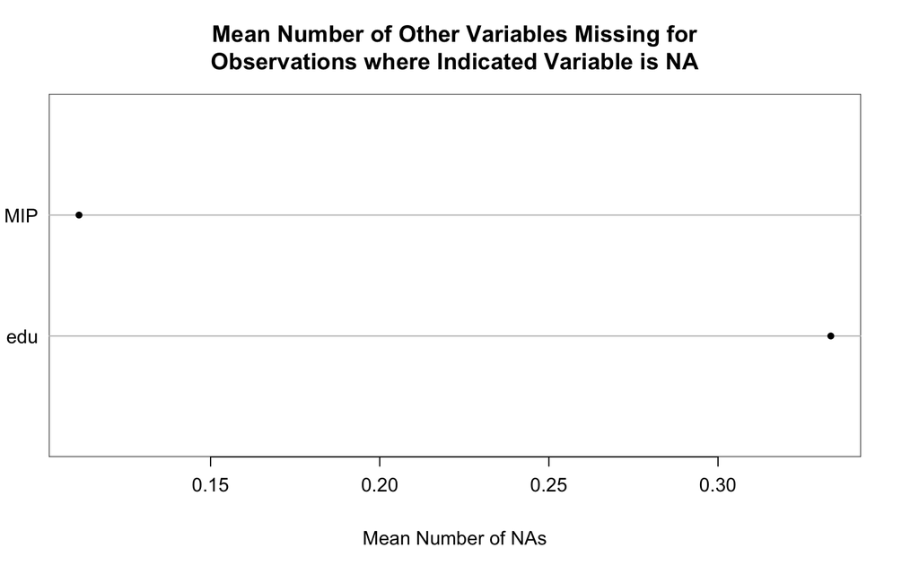

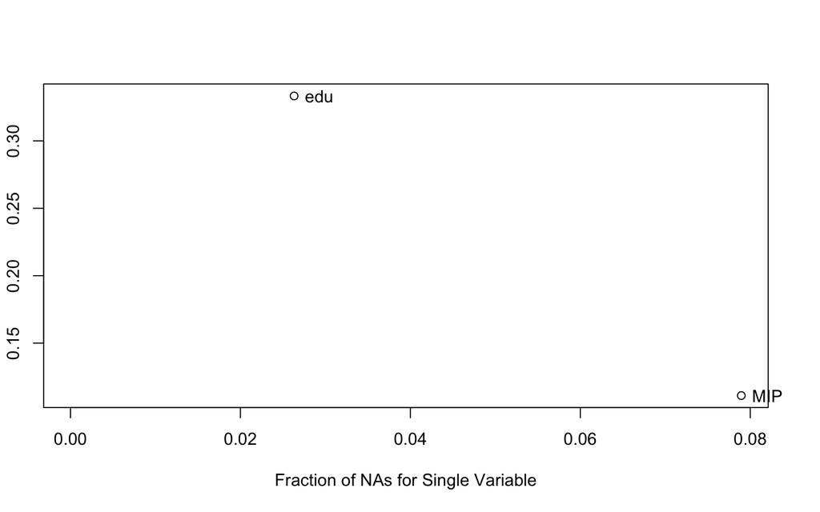

```r
naplot(naclus(chap))
```

There is one observation missing both `edu` and `MIP`. There are an additional 10 observations missing either `edu` or `MIP`. `edu` has < 3% of all observations missing, and `MIP` has approximately 8% of all observations missing.

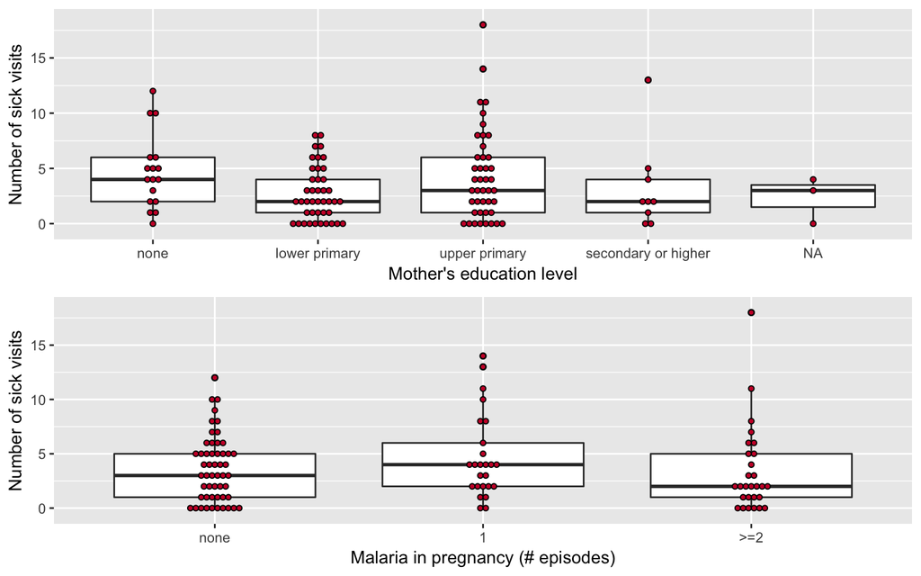

```r
p4 <- ggplot(chap, aes(x = edu, y = sick_sum)) +
  geom_boxplot() +
  geom_dotplot(binaxis = "y", stackdir = "center", dotsize = 0.5, fill = "#CC0033", binwidth=1) +
  labs(x = "Mother's education level", y = "Number of sick visits")

chapMIP <- chap %>% filter(complete.cases(MIP))

p5 <- ggplot(chapMIP, aes(x = MIP, y = sick_sum)) +
  geom_boxplot() +
  geom_dotplot(binaxis = "y", stackdir = "center", dotsize = 0.5, fill = "#CC0033", binwidth=1) +
  labs(x = "Malaria in pregnancy (# episodes)", y = "Number of sick visits")

gridExtra::grid.arrange(p4, p5, nrow=2)
```

There do not appear to be dramatic differences in number of sick visits according to maternal education or malaria in pregnancy.

**Scatterplot matrix:**

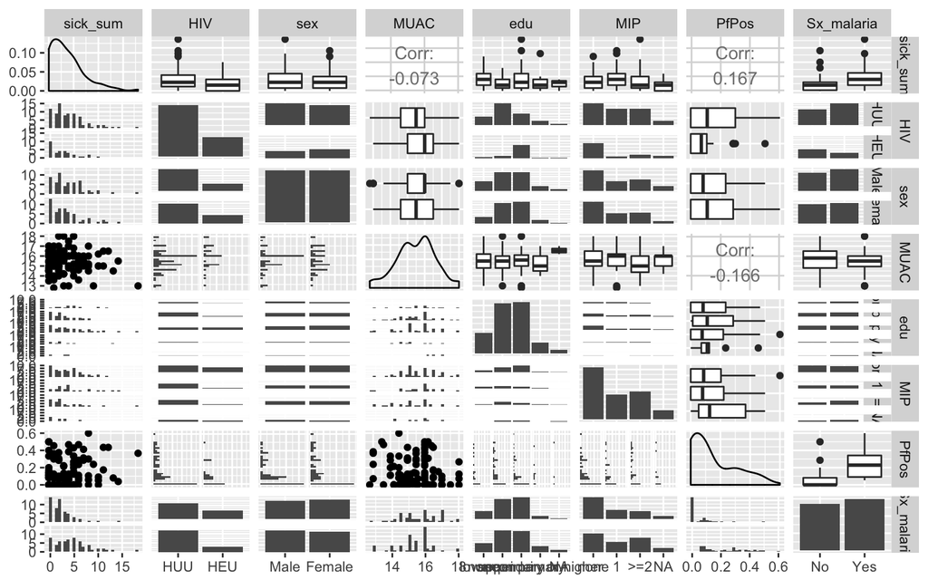

```r
chap2 <- chap %>% select(sick_sum, HIV, sex, MUAC, edu, MIP, PfPos, Sx_malaria)

GGally::ggpairs(data = chap2)
```

## 10.2 Model selection

**Spearman rho squared plot:**

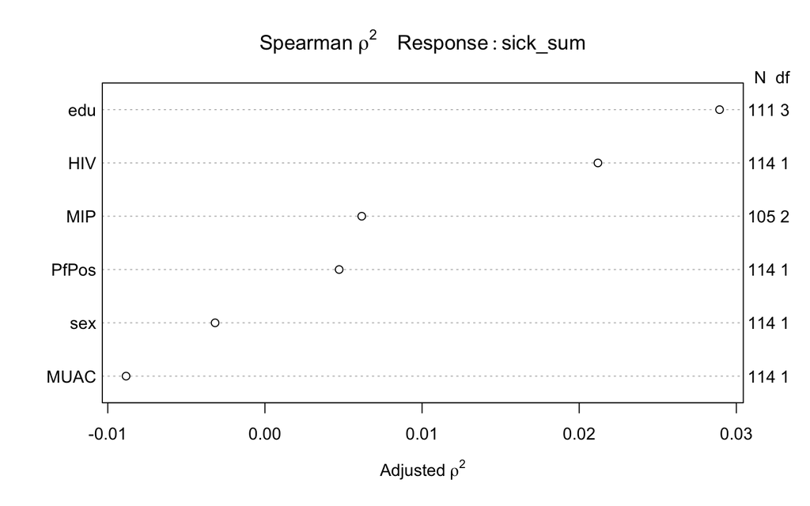

```r
plot(spearman2(sick_sum ~ HIV + sex + MUAC + edu + MIP + PfPos, data = chap2))
```

Don’t have a lot of df to spare. Will focus on edu, HIV, MIP, and PfPos.

**Simple imputation for the missing values for `edu` and `MIP`:**

```r
set.seed(20180307)
chap3 <- chap %>%
  impute_cart(MIP ~ .) %>%
  impute_cart(edu ~ .)

chap4 <- chap3 %>%
  select(sick_sum, PfPos, Sx_malaria, HIV, sex, MUAC, edu, MIP)

skim(chap4)
```

```
Skim summary statistics
 n obs: 114
 n variables: 8

Variable type: factor
   variable missing complete   n n_unique
        edu       0      114 114        4
        HIV       0      114 114        2
        MIP       0      114 114        3
        sex       0      114 114        2
 Sx_malaria       0      114 114        2
                        top_counts ordered
 low: 45, upp: 43, non: 17, sec: 9    TRUE
           HUU: 83, HEU: 31, NA: 0   FALSE
    non: 57, >=2: 31, 1: 26, NA: 0    TRUE
           Mal: 57, Fem: 57, NA: 0   FALSE
            Yes: 60, No: 54, NA: 0   FALSE

Variable type: numeric
 variable missing complete   n  mean   sd   p0  p25 median   p75 p100
     MUAC       0      114 114 15.5  1.13 12.8 14.8 15.5   16.15 18
    PfPos       0      114 114  0.15 0.15  0    0    0.087  0.26  0.6
 sick_sum       0      114 114  3.65 3.46  0    1    3      5    18
```

## 10.3 Fit a model

**Poisson regression:**

```r
m1 <- glm(sick_sum ~ HIV + edu + MIP + PfPos, family = "poisson", data = chap4)
summary(m1)
```

```
Call:
glm(formula = sick_sum ~ HIV + edu + MIP + PfPos, family = "poisson",
    data = chap4)

Deviance Residuals:
    Min       1Q   Median       3Q      Max
-3.3406  -1.5248  -0.3049   0.5862   4.0700

Coefficients:
            Estimate Std. Error z value Pr(>|z|)
(Intercept)  1.23999    0.08668  14.305  < 2e-16 ***
HIVHEU      -0.53472    0.14029  -3.812 0.000138 ***
edu.L       -0.06616    0.14865  -0.445 0.656259
edu.Q        0.00541    0.12663   0.043 0.965922
edu.C       -0.53838    0.09781  -5.504  3.7e-08 ***
MIP.L       -0.10150    0.09249  -1.097 0.272430
MIP.Q       -0.24536    0.09398  -2.611 0.009036 **
PfPos        0.92234    0.30950   2.980 0.002882 **
---
Signif. codes:  0 '***' 0.001 '**' 0.01 '*' 0.05 '.' 0.1 ' ' 1

(Dispersion parameter for poisson family taken to be 1)

    Null deviance: 372.47  on 113  degrees of freedom
Residual deviance: 308.89  on 106  degrees of freedom
AIC: 615.31

Number of Fisher Scoring iterations: 5
```

Check goodness of fit of this model:

```r
1 - pchisq(deviance(m1), df.residual(m1))
```

```
[1] 0
```

The *p* value = 0, suggesting a bad fit for the model (null hypothesis is that the model is correctly specified, so the low *p* value suggests that we reject the null hypothesis).

The residual deviance of 309 with 106 degrees of freedom (309/106) = 2.9, which is much greater than 1 and shows that the model does not fit well, despite a few significant predictors. Can check for over-dispersion by running a quasi-poisson model.

```r
m2 <- glm(sick_sum ~ HIV + edu + MIP + PfPos, family = "quasipoisson", data = chap4)
summary(m2)
```

```
Call:
glm(formula = sick_sum ~ HIV + edu + MIP + PfPos, family = "quasipoisson",
    data = chap4)

Deviance Residuals:
    Min       1Q   Median       3Q      Max
-3.3406  -1.5248  -0.3049   0.5862   4.0700

Coefficients:
            Estimate Std. Error t value Pr(>|t|)
(Intercept)  1.23999    0.14322   8.658 5.81e-14 ***
HIVHEU      -0.53472    0.23179  -2.307  0.02300 *
edu.L       -0.06616    0.24561  -0.269  0.78816
edu.Q        0.00541    0.20923   0.026  0.97942
edu.C       -0.53838    0.16161  -3.331  0.00119 **
MIP.L       -0.10150    0.15281  -0.664  0.50799
MIP.Q       -0.24536    0.15529  -1.580  0.11708
PfPos        0.92234    0.51138   1.804  0.07413 .
---
Signif. codes:  0 '***' 0.001 '**' 0.01 '*' 0.05 '.' 0.1 ' ' 1

(Dispersion parameter for quasipoisson family taken to be 2.730033)

    Null deviance: 372.47  on 113  degrees of freedom
Residual deviance: 308.89  on 106  degrees of freedom
AIC: NA

Number of Fisher Scoring iterations: 5
```

The dispersion parameter shows us that the variance is ~2.73 times larger than the mean. Comparing the two models, we also see that though the coefficients are the same, the standard erros appear to be under-estimated by the Poisson regression compared to quasi-Poisson. So I think there may be a problem with over-dispersion here.

(From my understanding, the assumption for Poisson regression is that variance equals the expected values; for quasi-Poisson regression, the assumption is that variance is a linear function of the mean).

- Can check to see if the variance of the residuals is proportional to the mean:
- plot square of the residual to the predicted mean
- black line for Poisson assumed variance
- green line for quasi-Poisson assumed variance
- blue curve for smoothed mean of the square of the residual

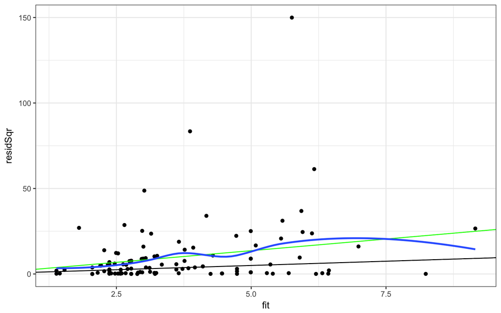

```r
m1Diag <- data.frame(chap4, link=predict(m1, type="link"),
                     fit=predict(m1, type="response"),
                     pearson=residuals(m1,type="pearson"),
                     resid=residuals(m1,type="response"),
                     residSqr=residuals(m1,type="response")^2)

ggplot(data=m1Diag, aes(x=fit, y=residSqr)) +
  geom_point() +
  geom_abline(intercept = 0, slope = 1) +
  geom_abline(intercept = 0, slope = summary(m2)$dispersion,
              color="green") +
  stat_smooth(method="loess", se = FALSE) +
  theme_bw()
```

The blue line is better approximated by the green (quasi-Poisson) line as compared to the black (Poisson), however, would ideally the blue curve would be straight and collinear with the green line. Deviation from the green line shows some concern that the variance may not be proportional to the mean.

# 11 Task 11: Logistic Regression Model

`Sx_malaria` will be the outcome variable. It is a binary variable that denotes whether a subject had 1 or more episodes of symptomatic malaria (uncomplicated or severe). Candidate predictor variables include `HIV`, `sex`, `MUAC`, `edu`, and `MIP`.

## 11.1 Model selection

**Spearman rho-squared plot:**

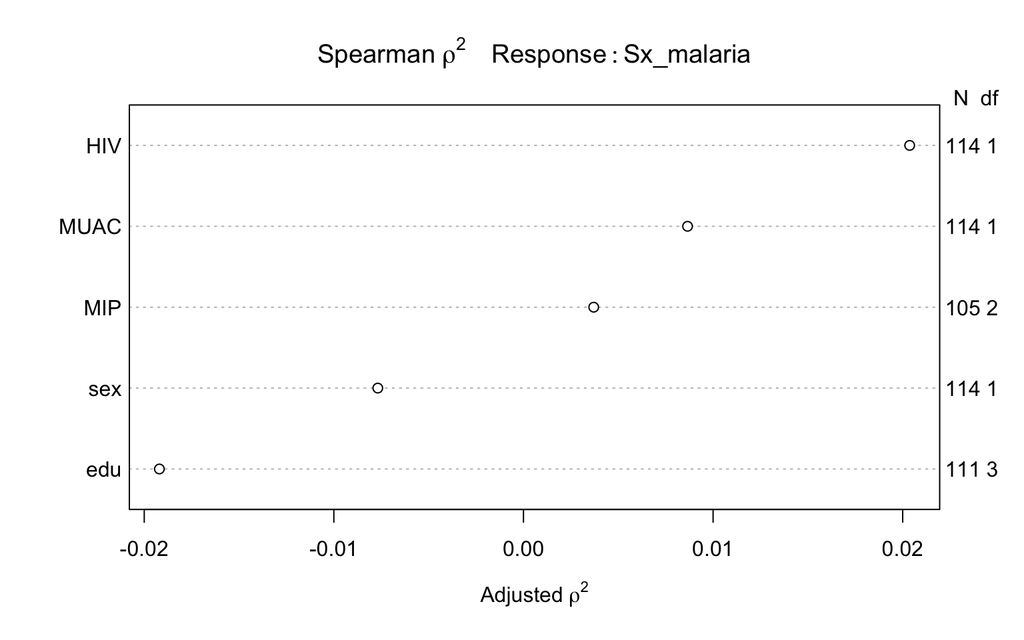

```r
plot(spearman2(Sx_malaria ~ HIV + sex + MUAC + edu + MIP, data = chap2))
```

Again, given the small sample size, I have limited degrees of freedom. I will focus on `HIV`, `MUAC`, and `MIP`.

## 11.2 Fit a model

```r
m1_glm <- glm(Sx_malaria ~ HIV + MUAC + MIP, family = "binomial", data = chap4)

summary(m1_glm)
```

```
Call:
glm(formula = Sx_malaria ~ HIV + MUAC + MIP, family = "binomial",
    data = chap4)

Deviance Residuals:
    Min       1Q   Median       3Q      Max
-1.6465  -1.1961   0.8059   1.1008   1.5382

Coefficients:
            Estimate Std. Error z value Pr(>|z|)
(Intercept)   3.4017     2.7442   1.240    0.215
HIVHEU       -0.6028     0.4649  -1.297    0.195
MUAC         -0.1986     0.1771  -1.121    0.262
MIP.L         0.4078     0.3381   1.206    0.228
MIP.Q         0.1203     0.3874   0.310    0.756

(Dispersion parameter for binomial family taken to be 1)

    Null deviance: 157.72  on 113  degrees of freedom
Residual deviance: 151.34  on 109  degrees of freedom
AIC: 161.34

Number of Fisher Scoring iterations: 4
```

The Wald Z tests show that none of the predictor variables has a statistically significant effect associated with change in the log odds of having symptomatic malaria.

Examine the odds ratio coefficients and confidence intervals:

```r
exp(coef(m1_glm))
```

```
(Intercept)      HIVHEU        MUAC       MIP.L       MIP.Q
 30.0142823   0.5472796   0.8198415   1.5034466   1.1278057
```

```r
exp(confint(m1_glm))
```

```
                2.5 %      97.5 %
(Intercept) 0.1491388 7686.445416
HIVHEU      0.2166019    1.356451
MUAC        0.5736212    1.155566
MIP.L       0.7790841    2.957631
MIP.Q       0.5238848    2.417385
```

All of the coefficient confidence intervals cross 1, indicating no statistically significant effect.

```r
dd <- datadist(chap4)
options(datadist="dd", contrasts=c("contr.treatment", "contr.treatment"))

m1_lrm <- lrm(Sx_malaria ~ HIV + MUAC + MIP, data = chap4, x=TRUE, y=TRUE)
m1_lrm
```

```
Logistic Regression Model

 lrm(formula = Sx_malaria ~ HIV + MUAC + MIP, data = chap4, x = TRUE,
     y = TRUE)

                      Model Likelihood     Discrimination    Rank Discrim.
                         Ratio Test           Indexes           Indexes
 Obs           114    LR chi2      6.38    R2       0.073    C       0.627
  No            54    d.f.            4    g        0.557    Dxy     0.255
  Yes           60    Pr(> chi2) 0.1727    gr       1.745    gamma   0.259
 max |deriv| 3e-07                         gp       0.133    tau-a   0.128
                                           Brier    0.236

           Coef    S.E.   Wald Z Pr(>|Z|)
 Intercept  3.1624 2.7512  1.15  0.2504
 HIV=HEU   -0.6028 0.4649 -1.30  0.1947
 MUAC      -0.1986 0.1771 -1.12  0.2621
 MIP=1      0.1410 0.5065  0.28  0.7807
 MIP=>=2    0.5767 0.4781  1.21  0.2278
```

This does not look to be a very useful model. The Nagelkerke R<sup>2</sup> is 0.073, which is rather poor. The C statistic is only 0.627, indicating poor discrimination of the model (only slightly better than random guessing). The likelihood ratio test shows a non-significant *p* value of 0.17.

Validate the model:

```r
set.seed(20180308)
validate(m1_lrm, B = 100)
```

```
          index.orig training   test optimism index.corrected   n
Dxy           0.2549   0.3116 0.2082   0.1034          0.1515 100
R2            0.0726   0.1075 0.0475   0.0600          0.0127 100
Intercept     0.0000   0.0000 0.0439  -0.0439          0.0439 100
Slope         1.0000   1.0000 0.6775   0.3225          0.6775 100
Emax          0.0000   0.0000 0.0940   0.0940          0.0940 100
D             0.0472   0.0758 0.0276   0.0482         -0.0010 100
U            -0.0175  -0.0175 0.0133  -0.0309          0.0133 100
Q             0.0647   0.0933 0.0142   0.0791         -0.0144 100
B             0.2359   0.2266 0.2470  -0.0204          0.2563 100
g             0.5570   0.6748 0.4313   0.2435          0.3135 100
gp            0.1331   0.1549 0.1046   0.0504          0.0828 100
```

```r
C <- 0.5 + (0.1515/2)
C
```

```
[1] 0.57575
```

The corrected C statistic is 0.57 and corrected Nagelkerke R<sup>2</sup> is 0.013, not very good at all.

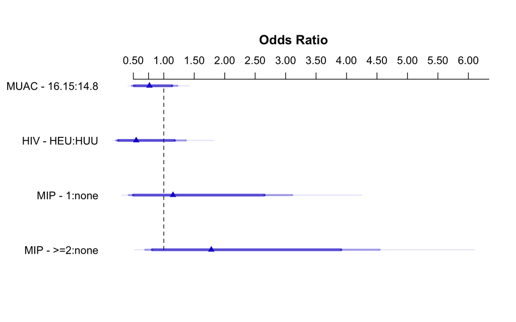

```r
plot(summary(m1_lrm))
```

Kate Dobbs

2018-03-08 11:45:10